# Notebook R - Proyecto Introducción a la Ciencia de Datos

Grupo 8

Procesamiento de Datos

```r
library(tidyverse)
library(readxl)
library(ggcorrplot)
library(readr)
```

# Procesamiento de datos - Población

Se procesan los datos de la población obtenidos del censo.

```r
poblacion <- read_csv2("Censo2017_Manzanas.csv")
names(poblacion)
```

```
##  [1] "REGION"         "PROVINCIA"      "COMUNA"         "DC"
##  [5] "AREA"           "ZC_LOC"         "MZ_ENT"         "ID_ZONA_LOC"
##  [9] "ID_MANZENT"     "PERSONAS"       "HOMBRES"        "MUJERES"
## [13] "EDAD_0A5"       "EDAD_6A14"      "EDAD_15A64"     "EDAD_65YMAS"
## [17] "INMIGRANTES"    "PUEBLO"         "VIV_PART"       "VIV_COL"
## [21] "VPOMP"          "TOTAL_VIV"      "CANT_HOG"       "P01_1"
## [25] "P01_2"          "P01_3"          "P01_4"          "P01_5"
## [29] "P01_6"          "P01_7"          "P03A_1"         "P03A_2"
## [33] "P03A_3"         "P03A_4"         "P03A_5"         "P03A_6"
## [37] "P03B_1"         "P03B_2"         "P03B_3"         "P03B_4"
## [41] "P03B_5"         "P03B_6"         "P03B_7"         "P03C_1"
## [45] "P03C_2"         "P03C_3"         "P03C_4"         "P03C_5"
## [49] "MATACEP"        "MATREC"         "MATIRREC"       "P05_1"
## [53] "P05_2"          "P05_3"          "P05_4"          "REGION_15R"
## [57] "PROVINCIA_15R"  "COMUNA_15R"     "ID_MANZENT_15R"
```

```r
pob <- poblacion %>% group_by(REGION) %>% summarise(POBLACION = sum(PERSONAS))
```

### Se procesa datos de Proyeccion de población al 2030

Datos requeridos para predecir la demanda del agua en función del crecimiento poblacional

```r
library(readxl)
poblacion <- read_xlsx("proyecciones-2002-2035-comuna-y-área-urbana-y-rural.xlsx")

# Se obtiene la poblacion por comuna
poblacion_comuna <- poblacion %>%
  janitor::clean_names() %>%  group_by(region, nombre_region, comuna, nombre_comuna) %>%
  summarise_at(vars(poblacion_2002:poblacion_2030), sum, na.rm=TRUE)

# Se obtiene la población por region
poblacion_region <- poblacion %>%
  janitor::clean_names() %>%  group_by(region, nombre_region) %>%
  summarise_at(vars(poblacion_2002:poblacion_2030), sum, na.rm=TRUE)

# se pivotea la tabla comuna
poblacion_comuna <- poblacion_region %>% select(-nombre_region) %>%
  pivot_longer(!region, names_to = "periodo", values_to = "poblacion") %>%
  mutate(periodo = as.numeric(str_remove_all(periodo , "poblacion_")))

# se pivotea la tabla region
poblacion_region <- poblacion_region %>% select(-nombre_region) %>%
  pivot_longer(!region, names_to = "periodo", values_to = "poblacion") %>%
  mutate(periodo = as.numeric(str_remove_all(periodo , "poblacion_")))

head(poblacion_comuna)
```

```
## # A tibble: 6 x 3
## # Groups:   region [1]
##   region periodo poblacion
##    <dbl>   <dbl>     <dbl>
## 1      1    2002    246265
## 2      1    2003    251625
## 3      1    2004    257394
## 4      1    2005    263141
## 5      1    2006    268976
## 6      1    2007    275014
```

```r
head(poblacion_region)
```

```
## # A tibble: 6 x 3
## # Groups:   region [1]
##   region periodo poblacion
##    <dbl>   <dbl>     <dbl>
## 1      1    2002    246265
## 2      1    2003    251625
## 3      1    2004    257394
## 4      1    2005    263141
## 5      1    2006    268976
## 6      1    2007    275014
```

```r
# Se guarda en csv para proceso en python
write.csv(poblacion_region, "poblacion_region.csv")
write.csv(poblacion_comuna, "poblacion_comuna.csv")
```

## Revisión data set estaciones

```r
estaciones <- read_csv("cr2_prDaily_2020v2/cr2_prDaily_2020_stations.txt")
head(estaciones)
```

```
## # A tibble: 6 x 15
##   codigo_estacion institucion fuente  nombre             altura latitud longitud
##             <dbl> <chr>       <chr>   <chr>               <dbl>   <dbl>    <dbl>
## 1         1000005 DGA         dga_web Visviri              4080   -17.6    -69.5
## 2         1200002 DGA         dga_web Villa Industrial ~   4080   -17.8    -69.7
## 3         1200003 DGA         dga_web Humapalca            3980   -17.8    -69.7
## 4         1201005 DGA         dga_web Rio Caracarani En~   3908   -17.8    -69.7
## 5         1201010 DGA         dga_web Alcerreca            3990   -18.0    -69.7
## 6         1201003 DGA         dga_web Rio Lluta En Alce~   3550   -18.0    -69.6
## # ... with 8 more variables: codigo_cuenca <dbl>, nombre_cuenca <chr>,
## #   codigo_sub_cuenca <dbl>, nombre_sub_cuenca <chr>,
## #   inicio_observaciones <date>, fin_observaciones <date>,
## #   cantidad_observaciones <dbl>, inicio_automatica <chr>
```

```r
## Construcccion data precipitaciones
prep <- read_csv("cr2_prDaily_2020v2/cr2_prDaily_2020.txt",
                 col_names = FALSE, na = c("", "NA",-9999))

caud <- read_csv2("caudales_rio_maipo.csv",na = c("", "NA",-9999))
```

# Transformación de datos - Caudales

```r
ruta1 <- "Caudales/Caudales Medios Diarios 14_05_2022 17_08.xls"
ruta2 <- "Caudales/Caudales Medios Diarios 14_05_2022 17_12.xls"
ruta3 <- "Caudales/Caudales Medios Diarios 14_05_2022 17_13 (1).xls"
ruta4 <- "Caudales/Caudales Medios Diarios 14_05_2022 17_13.xls"
ruta5 <- "Caudales/Caudales Medios Diarios 14_05_2022 17_14.xls"
ruta6 <- "Caudales/Caudales Medios Diarios 14_05_2022 17_15.xls"

# Leemos las hojas del excel
readxl::excel_sheets(ruta1)
```

```
## [1] "CANAL QUELTEHUE"              "ESTERO ARRAYAN EN LA MONTOSA"
```

```r
readxl::excel_sheets(ruta2)
```

```
## [1] "ESTERO PUANGUE EN RUTA 78"       "ESTERO YERBA LOCA ANTES JUNTA S"
## [3] "QUEBRADA RAMON EN RECINTO EMOS"  "RIO ANGOSTURA EN VALDIVIA DE PA"
## [5] "RIO COLINA EN PELDEHUE"
```

```r
readxl::excel_sheets(ruta3)
```

```
## [1] "RIO MAIPO EN EL MANZANO"    "RIO MAIPO EN LAS HUALTATAS"
## [3] "RIO MAIPO EN QUELTEHUES"    "RIO MAPOCHO EN EL TREBAL"
```

```r
readxl::excel_sheets(ruta4)
```

```
## [1] "RIO COLORADO ANTES JUNTA RIO MA" "RIO COLORADO ANTES JUNTA RIO OL"
```

```r
readxl::excel_sheets(ruta5)
```

```
## [1] "RIO MAPOCHO EN LOS ALMENDROS"    "RIO OLIVARES ANTES JUNTA RIO CO"
```

```r
readxl::excel_sheets(ruta6)
```

```
## [1] "RIO SAN FRANCISCO ANTES JUNTA E" "RIO VOLCAN EN QUELTEHUES"
```

Creamos funcion que carga y procesa la data de cada hoja

```r
caudales <- function(ruta){
h1 <- ruta %>%
  excel_sheets() %>%
  set_names() %>%
  map_dfr(read_excel, path = ruta, skip = 9, .id = "nombre") %>%
  janitor::clean_names() %>%   mutate(year = x1 ) %>%
  select(year, everything()) %>% mutate(year = case_when(year == "AÑO: 2018" ~ 2018,
                                         year == "AÑO: 2019" ~ 2019,
                                         year == "AÑO: 2020" ~ 2020,
                                         year == "AÑO: 2021" ~ 2021
                                         )) %>% fill(year) %>%
  select(nombre, year, x1, x2, x4, x6, x8,x10,x12,x14,x16,x18,x20,x22,x25)

names(h1) <- c("nombre", "year", "day", month.name)

h1 <- h1 %>% filter(day %in% as.character(1:31))
h1
}

c1 <- caudales(ruta1)
c2 <- caudales(ruta2)
c3 <- caudales(ruta3)
c4 <- caudales(ruta4)
c5 <- caudales(ruta5)
c6 <- caudales(ruta6)

caudales_faltantes <- c1 %>% bind_rows(c2) %>% bind_rows(c3) %>%
  bind_rows(c4) %>% bind_rows(c5) %>% bind_rows(c6)

caudales_faltantes_pivot <-caudales_faltantes %>% pivot_longer(cols = January:December, names_to = "mes", values_to = "Caudal")
glimpse(caudales_faltantes_pivot)
```

```
## Rows: 31,620
## Columns: 5
## $ nombre <chr> "CANAL QUELTEHUE", "CANAL QUELTEHUE", "CANAL QUELTEHUE", "CANAL~
## $ year   <dbl> 2018, 2018, 2018, 2018, 2018, 2018, 2018, 2018, 2018, 2018, 201~
## $ day    <chr> "1", "1", "1", "1", "1", "1", "1", "1", "1", "1", "1", "1", "2"~
## $ mes    <chr> "January", "February", "March", "April", "May", "June", "July",~
## $ Caudal <chr> NA, NA, "16.800000000000001", "17.399999999999999", "12.9", "10~
```

```r
head(caudales_faltantes_pivot)
```

```
## # A tibble: 6 x 5
##   nombre           year day   mes      Caudal
##   <chr>           <dbl> <chr> <chr>    <chr>
## 1 CANAL QUELTEHUE  2018 1     January  <NA>
## 2 CANAL QUELTEHUE  2018 1     February <NA>
## 3 CANAL QUELTEHUE  2018 1     March    16.800000000000001
## 4 CANAL QUELTEHUE  2018 1     April    17.399999999999999
## 5 CANAL QUELTEHUE  2018 1     May      12.9
## 6 CANAL QUELTEHUE  2018 1     June     10.800000000000001
```

```r
#write.csv(caudales_faltantes_pivot,"caudales_2018-2021.csv")
```

## Procesamiento datos generación electrica

Conjunto de datos obtenidos de http://energiaabierta.cl/visualizaciones/generacion-bruta-ernc/

Se debe generar un proceso que lea las 53 hojas del excel en las filas correspondiente a la generación por tipo de planta y por tipo de generación. Después se debe unir en un solo data frame. Luego unirlo con las plantas pertenecientes a la RM.

Los datos vienen ingestados en diferentes hojas de una planilla excel.

#### Se crea función que automatice el proceso

```r
generacion_electrica <- function(periodo){
h1 <- periodo %>%
  set_names() %>%
  map_dfr(read_excel, path = ruta, range = "B386:MY406" , .id = "nombre", col_names=F)

h2 <- h1 %>%  janitor::clean_names() %>%
  filter(x1 == "PROPIETARIO" | x1 == "Total" | x1 == "TECNOLOGÍA" | x1 == "CÓDIGO CENTRAL" | x1 == "FUENTE DE ENERGÍA"| x1 == "CENTRAL" | x1 == "UNIDAD") %>%
  rename(descripcion = x1) %>% select(-1)

nombres <- h2[,1] %>% as_vector()

h4 <- t(h2) %>% as_tibble() %>%  janitor::clean_names() %>% filter(v1 !="PROPIETARIO", v1 != "TOTAL")
names(h4) <- nombres

h5 <- h4 %>% mutate( sistema_periodo = periodo ) %>%
  select(sistema_periodo, everything())
}
```

Se aplica la función a los sistemas y periodos requeridos

```r
ruta <- "Generacion_Bruta.xlsx" # Datos de la SGE
hojas <- readxl::excel_sheets(ruta)
hojas
```

```
##  [1] "TAPA"                       "99sing"
##  [3] "00sing"                     "01sing"
##  [5] "02sing"                     "03sing"
##  [7] "04sing"                     "05sing"
##  [9] "06sing"                     "07sing"
## [11] "08sing"                     "09sing"
## [13] "10sing"                     "11sing"
## [15] "12sing"                     "13sing"
## [17] "14sing"                     "15sing"
## [19] "16sing"                     "17sing"
## [21] "96sic"                      "97sic"
## [23] "98sic"                      "99sic"
## [25] "00sic"                      "01sic"
## [27] "02sic"                      "03sic"
## [29] "04sic"                      "05sic"
## [31] "06sic"                      "07sic"
## [33] "08sic"                      "09sic"
## [35] "10sic"                      "11sic"
## [37] "12sic"                      "13sic"
## [39] "14sic"                      "15sic"
## [41] "16sic"                      "17sic"
## [43] "18sen"                      "19sen"
## [45] "20sen"                      "21sen"
## [47] "22sen"                      "Res_Mes"
## [49] "Res_GMax"                   "Res_Año_Tipo Gen"
## [51] "Gráf_Mes"                   "Información Centrales SING"
## [53] "Información Centrales SIC"
```

```r
hojas <- hojas[32:47] # se seleccionan los datos desde el 2007 en adelante
```

```r
periodo <- hojas[15]

# se aplica la función de manera manual ya que tarda mucho la carga
p_07sic <- generacion_electrica("07sic")
p_08sic <- generacion_electrica("08sic")
p_09sic <- generacion_electrica("09sic")
p_10sic <- generacion_electrica("10sic")
p_11sic <- generacion_electrica("11sic")
p_12sic <- generacion_electrica("12sic")
p_13sic <- generacion_electrica("13sic")
p_14sic <- generacion_electrica("14sic")
p_15sic <- generacion_electrica("15sic")
p_16sic <- generacion_electrica("16sic")
p_17sic <- generacion_electrica("17sic")
p_18sen <- generacion_electrica("18sen") # a partir del 2018 se intregra el sistema electrico
p_19sen <- generacion_electrica("19sen")
p_20sen <- generacion_electrica("20sen")
p_21sen <- generacion_electrica("21sen")

generacion_unificada <- bind_rows(p_07sic, p_08sic, p_09sic, p_10sic, p_11sic, p_12sic, p_13sic,
                   p_14sic, p_15sic, p_16sic, p_17sic, p_18sen, p_19sen, p_20sen, p_21sen)
```

```r
# write.csv(generacion_unificada,"generacion_hidroelectrica_unificada.csv")
```

## Generación hidroeléctrica región metropolitana

Se cargan los datos de generación electrica de la region metropolitana cruzados con las generadoras en python.

```r
generacion_hidroelectrica_RM_MWh <- read_excel("C:/Users/amalv/Dropbox/MIA/Introducción a la Ciencia de Datos/Proyecto/generacion_hidroelectrica_RM_MWh.xlsx")
names(generacion_hidroelectrica_RM_MWh) <- c("Year","Embalse","Pasada", "x1","x2")
head(generacion_hidroelectrica_RM_MWh)
```

```
## # A tibble: 6 x 5
##    Year  Embalse    Pasada x1    x2
##   <dbl>    <dbl>     <dbl> <lgl> <chr>
## 1  2007 12877960  9280680. NA    Fuente: CDEC SIC (2007-2017) - CDEC SEN (2018-~
## 2  2008 13871632  9630270. NA    <NA>
## 3  2009 14427619 10067017. NA    <NA>
## 4  2010 11759292  9438578. NA    <NA>
## 5  2011 11415284  9144675. NA    <NA>
## 6  2012 10658518  9387463. NA    <NA>
```

```r
generacion_hidroelectrica_RM_MWh
```

```
## # A tibble: 15 x 5
##     Year   Embalse    Pasada x1    x2
##    <dbl>     <dbl>     <dbl> <lgl> <chr>
##  1  2007 12877960   9280680. NA    Fuente: CDEC SIC (2007-2017) - CDEC SEN (201~
##  2  2008 13871632   9630270. NA    <NA>
##  3  2009 14427619  10067017. NA    <NA>
##  4  2010 11759292   9438578. NA    <NA>
##  5  2011 11415284   9144675. NA    <NA>
##  6  2012 10658518   9387463. NA    <NA>
##  7  2013  9544732   9898175. NA    <NA>
##  8  2014 11791559  11649949. NA    <NA>
##  9  2015 11615530  12171899. NA    <NA>
## 10  2016  7943559  11433903. NA    <NA>
## 11  2017  9423260  12145180. NA    <NA>
## 12  2018 10814515.  9821806. NA    <NA>
## 13  2019  9139456.  9134772. NA    <NA>
## 14  2020  9294491.  8973027. NA    <NA>
## 15  2021 10814515.  9821806. NA    <NA>
```

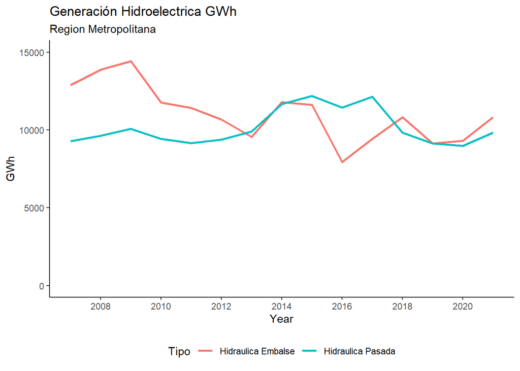

```r
generacion_hidroelectrica_RM_MWh  %>% ggplot()+
  geom_line(aes(x = Year, y =Embalse/1000, color="Hidraulica Embalse"), size=1)+
  geom_line(aes(x = Year, y =Pasada/1000, color="Hidraulica Pasada"), size = 1)+
  labs(title = "Generación Hidroelectrica GWh", subtitle = "Region Metropolitana", color = "Tipo",
       y = "GWh")  +theme_classic()+
  scale_y_continuous(limits = c(0,15000))+
  scale_x_continuous(breaks =  seq(2008,2020,2))+
  theme(legend.position="bottom")
```